# Introduction

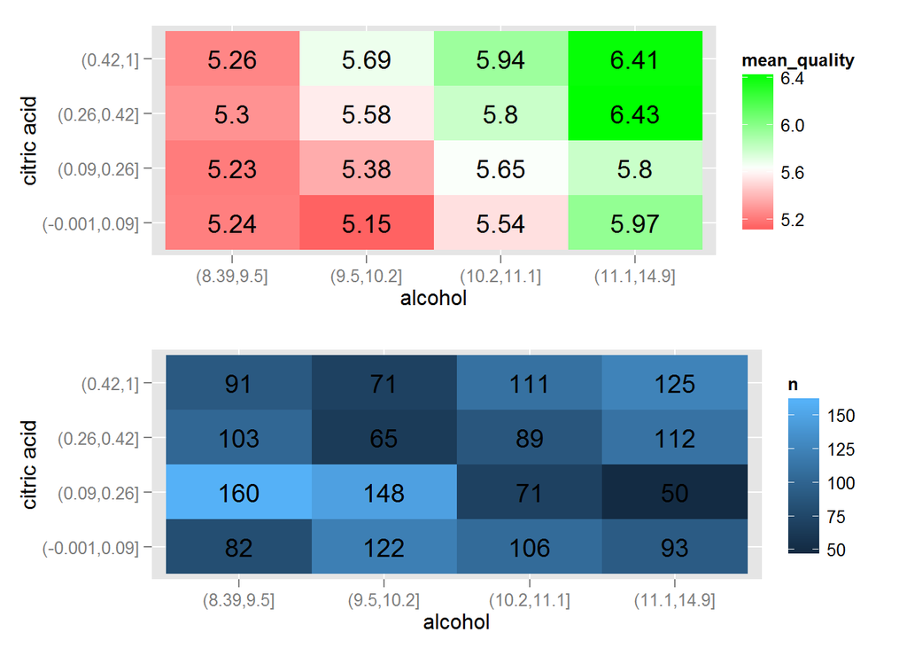

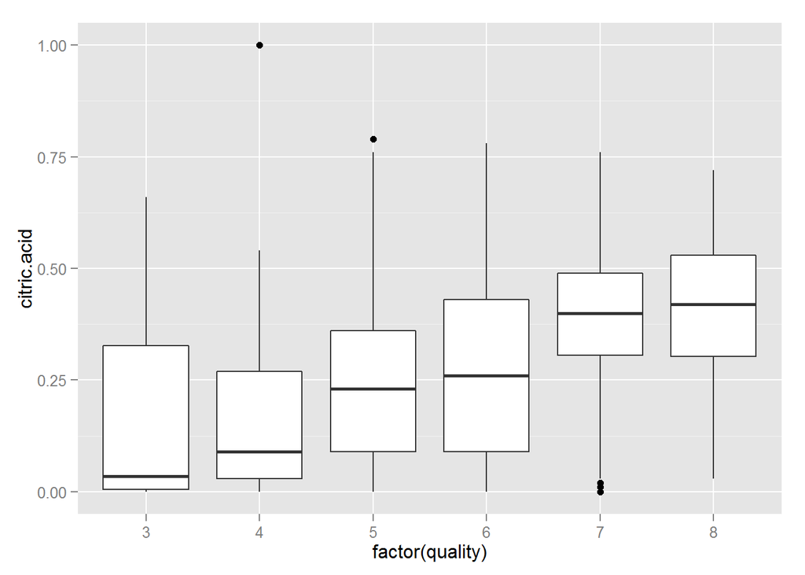

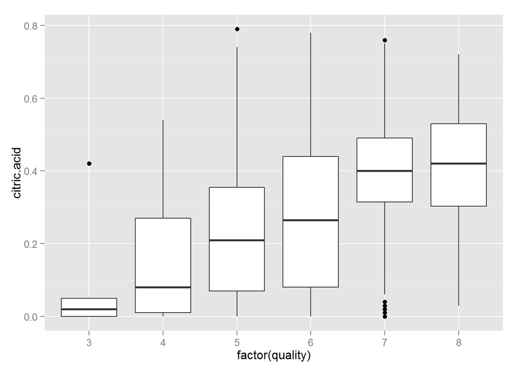

```
##
##  Pearson's product-moment correlation
##
## data:  wines$quality and wines$citric.acid
## t = 9.2875, df = 1597, p-value < 2.2e-16
## alternative hypothesis: true correlation is not equal to 0
## 95 percent confidence interval:
##  0.1793415 0.2723711
## sample estimates:
##       cor
## 0.2263725
```

```
##
##  Pearson's product-moment correlation
##
## data:  wines.exclude.low.alc$quality and wines.exclude.low.alc$citric.acid
## t = 10.0218, df = 1161, p-value < 2.2e-16
## alternative hypothesis: true correlation is not equal to 0
## 95 percent confidence interval:
##  0.2283933 0.3342336
## sample estimates:
##       cor
## 0.2821719
```

```
##
##  Pearson's product-moment correlation
##
## data:  wines.low.alc$quality and wines.low.alc$citric.acid
## t = 0.0951, df = 295, p-value = 0.9243
## alternative hypothesis: true correlation is not equal to 0
## 95 percent confidence interval:
##  -0.1083420  0.1192754
## sample estimates:
##         cor
## 0.005538476
```

More citric acid slightly increases wine quality. It turns out that this tendency does not hold true for wines with low alcohol content (first quartile). In this quartile citric acid concentration does not influence wine quality (correlation 0.005). Excluding these low alcohol wines increases correlation between citric acid and quality to 0.28 from 0.226.

# Multivariate Analysis

### Talk about some of the relationships you observed in this part of the investigation. Were there features that strengthened each other in terms of looking at your feature(s) of interest?

Alcohol and volatile acid concentrations strengthen each other in terms of looking at wine quality. Wine quality tends to rise towards more alcohol and less volatile acid. Average quality of wines is highest among wines, which have alcohol value in the fourth quartile and volatile acid concentration in the first quartile.

### Were there any interesting or surprising interactions between features?

It was interesting that citric acid, which had weak positive correlation with wine quality, did not influence quality of low alcohol percentage wines.

### OPTIONAL: Did you create any models with your dataset? Discuss the strengths and limitations of your model.

# Final Plots and Summary

### Plot One

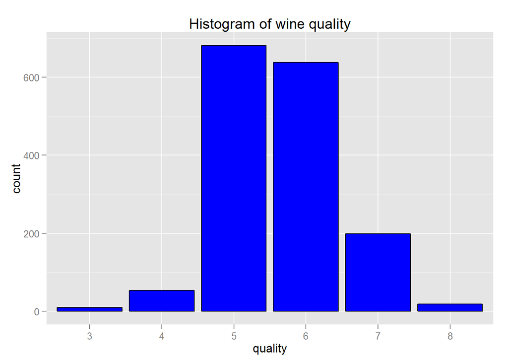

### Description One

Distribution of wine quality is close to normal distribution, with most wines having quality of 5 or 6. However, it is a bit left skewed with more wines having high quality scores (7 and 8) compared to low scores (3 and 4).

### Plot Two

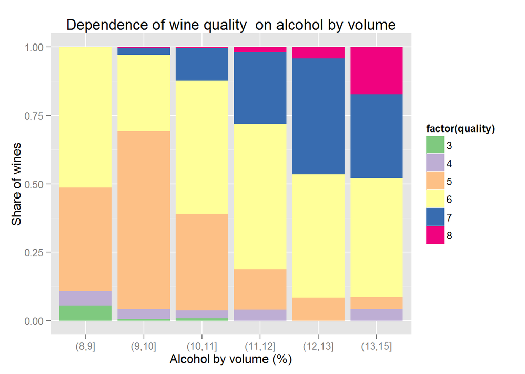

### Description Two

Share of high quality wines is higher among stronger wines. For example, 50% of wines that have 12 or more percent of alcohol are good quality wines (7 or 8), while less than 5% of wines with less than 10% of alcohol have similar quality.

### Plot Three

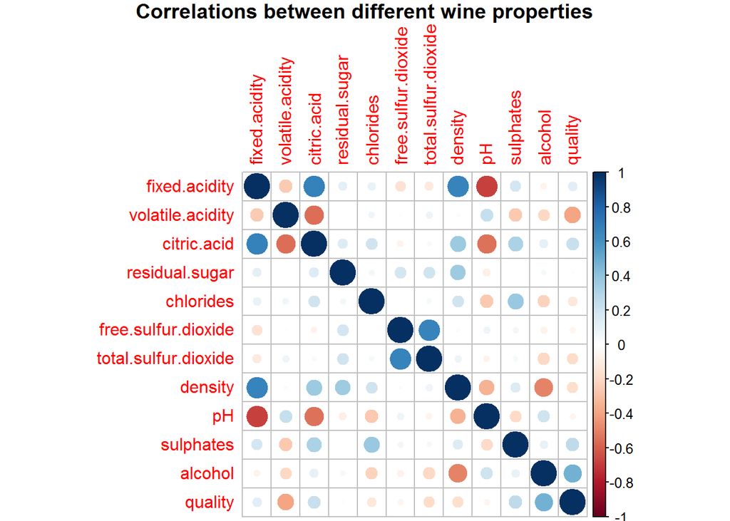

### Description Three

There is no single very good indicator of wine quality. Alcohol and volatile acid concentrations have strongest correlation with quality; however these are not really strong but rather weak to moderate.